# Reshaping Data

David Asare Kumi

9/27/2019

## Reshaping Data

- The goal is to tidy data.
1. Each variable forms a column.
2. Each observation forms a row.
3. Each table / file stores data about one kind of observation (e.g. people/hospitals).
- http://vita.had.co.nz/papers/tidy-data.pdf
- Leek, Taub, and Pineda 2011 PLoSOne.

### Start with reshaping

```r
library(reshape2)
library(dplyr)
data(mtcars)
dim(mtcars)
```

```
[1] 32 11
```

```r
names(mtcars)
```

```
 [1] "mpg"  "cyl"  "disp" "hp"   "drat" "wt"   "qsec" "vs"   "am"   "gear"
[11] "carb"
```

```r
head(mtcars)
```

```
                   mpg cyl disp  hp drat    wt  qsec vs am gear carb
Mazda RX4         21.0   6  160 110 3.90 2.620 16.46  0  1    4    4
Mazda RX4 Wag     21.0   6  160 110 3.90 2.875 17.02  0  1    4    4
Datsun 710        22.8   4  108  93 3.85 2.320 18.61  1  1    4    1
Hornet 4 Drive    21.4   6  258 110 3.08 3.215 19.44  1  0    3    1
Hornet Sportabout 18.7   8  360 175 3.15 3.440 17.02  0  0    3    2
Valiant           18.1   6  225 105 2.76 3.460 20.22  1  0    3    1
```

```r
glimpse(mtcars)
```

```
Observations: 32
Variables: 11
$ mpg  <dbl> 21.0, 21.0, 22.8, 21.4, 18.7, 18.1, 14.3, 24.4, 22.8, 19....
$ cyl  <dbl> 6, 6, 4, 6, 8, 6, 8, 4, 4, 6, 6, 8, 8, 8, 8, 8, 8, 4, 4, ...
$ disp <dbl> 160.0, 160.0, 108.0, 258.0, 360.0, 225.0, 360.0, 146.7, 1...
$ hp   <dbl> 110, 110, 93, 110, 175, 105, 245, 62, 95, 123, 123, 180, ...
$ drat <dbl> 3.90, 3.90, 3.85, 3.08, 3.15, 2.76, 3.21, 3.69, 3.92, 3.9...
$ wt   <dbl> 2.620, 2.875, 2.320, 3.215, 3.440, 3.460, 3.570, 3.190, 3...
$ qsec <dbl> 16.46, 17.02, 18.61, 19.44, 17.02, 20.22, 15.84, 20.00, 2...
$ vs   <dbl> 0, 0, 1, 1, 0, 1, 0, 1, 1, 1, 1, 0, 0, 0, 0, 0, 0, 1, 1, ...
$ am   <dbl> 1, 1, 1, 0, 0, 0, 0, 0, 0, 0, 0, 0, 0, 0, 0, 0, 0, 1, 1, ...
$ gear <dbl> 4, 4, 4, 3, 3, 3, 3, 4, 4, 4, 4, 3, 3, 3, 3, 3, 3, 4, 4, ...
$ carb <dbl> 4, 4, 1, 1, 2, 1, 4, 2, 2, 4, 4, 3, 3, 3, 4, 4, 4, 1, 2, ...
```

```r
summary(mtcars)
```

```
      mpg             cyl             disp             hp
 Min.   :10.40   Min.   :4.000   Min.   : 71.1   Min.   : 52.0
 1st Qu.:15.43   1st Qu.:4.000   1st Qu.:120.8   1st Qu.: 96.5
 Median :19.20   Median :6.000   Median :196.3   Median :123.0
 Mean   :20.09   Mean   :6.188   Mean   :230.7   Mean   :146.7
 3rd Qu.:22.80   3rd Qu.:8.000   3rd Qu.:326.0   3rd Qu.:180.0
 Max.   :33.90   Max.   :8.000   Max.   :472.0   Max.   :335.0
      drat             wt             qsec             vs
 Min.   :2.760   Min.   :1.513   Min.   :14.50   Min.   :0.0000
 1st Qu.:3.080   1st Qu.:2.581   1st Qu.:16.89   1st Qu.:0.0000
 Median :3.695   Median :3.325   Median :17.71   Median :0.0000
 Mean   :3.597   Mean   :3.217   Mean   :17.85   Mean   :0.4375
 3rd Qu.:3.920   3rd Qu.:3.610   3rd Qu.:18.90   3rd Qu.:1.0000
 Max.   :4.930   Max.   :5.424   Max.   :22.90   Max.   :1.0000
       am              gear            carb
 Min.   :0.0000   Min.   :3.000   Min.   :1.000
 1st Qu.:0.0000   1st Qu.:3.000   1st Qu.:2.000
 Median :0.0000   Median :4.000   Median :2.000
 Mean   :0.4062   Mean   :3.688   Mean   :2.812
 3rd Qu.:1.0000   3rd Qu.:4.000   3rd Qu.:4.000
 Max.   :1.0000   Max.   :5.000   Max.   :8.000
```

- First thing to do is melting the data set.

### Melting data frames

```r
mtcars$carname <-rownames(mtcars)
mtcars$carname
```

```
 [1] "Mazda RX4"           "Mazda RX4 Wag"       "Datsun 710"
 [4] "Hornet 4 Drive"      "Hornet Sportabout"   "Valiant"
 [7] "Duster 360"          "Merc 240D"           "Merc 230"
[10] "Merc 280"            "Merc 280C"           "Merc 450SE"
[13] "Merc 450SL"          "Merc 450SLC"         "Cadillac Fleetwood"
[16] "Lincoln Continental" "Chrysler Imperial"   "Fiat 128"
[19] "Honda Civic"         "Toyota Corolla"      "Toyota Corona"
[22] "Dodge Challenger"    "AMC Javelin"         "Camaro Z28"
[25] "Pontiac Firebird"    "Fiat X1-9"           "Porsche 914-2"
[28] "Lotus Europa"        "Ford Pantera L"      "Ferrari Dino"
[31] "Maserati Bora"       "Volvo 142E"
```

```r
carMelt <-melt(mtcars,id=c("carname","gear","cyl"),measure.vars=c("mpg","hp"))
head(carMelt,n=3)
```

```
        carname gear cyl variable value
1     Mazda RX4    4   6      mpg  21.0
2 Mazda RX4 Wag    4   6      mpg  21.0
3    Datsun 710    4   4      mpg  22.8
```

```r
tail(carMelt,n=3)
```

```
         carname gear cyl variable value
62  Ferrari Dino    5   6       hp   175
63 Maserati Bora    5   8       hp   335
64    Volvo 142E    4   4       hp   109
```

- There is one row for every mpg and one row for every hp.

### Casting data frames

```r
cylData <-dcast(carMelt,cyl~variable)
cylData
```

```
  cyl mpg hp
1   4  11 11
2   6   7  7
3   8  14 14
```

```r
cylData <-dcast(carMelt,cyl~variable,mean)
cylData
```

```
  cyl      mpg        hp
1   4 26.66364  82.63636
2   6 19.74286 122.28571
3   8 15.10000 209.21429
```

- Casting is used to re-summarize the data frame.

### Averaging Values

```r
library(datasets)
library(dplyr)
data(InsectSprays)
dim(InsectSprays)
```

```
[1] 72  2
```

```r
names(InsectSprays)
```

```
[1] "count" "spray"
```

```r
glimpse(InsectSprays)
```

```
Observations: 72
Variables: 2
$ count <dbl> 10, 7, 20, 14, 14, 12, 10, 23, 17, 20, 14, 13, 11, 17, 2...
$ spray <fct> A, A, A, A, A, A, A, A, A, A, A, A, B, B, B, B, B, B, B,...
```

```r
head(InsectSprays)
```

```
  count spray
1    10     A
2     7     A
3    20     A
4    14     A
5    14     A
6    12     A
```

```r
TapInsectSprays <-tapply(InsectSprays$count,InsectSprays$spray,sum)
TapInsectSprays
```

```
  A   B   C   D   E   F
174 184  25  59  42 200
```

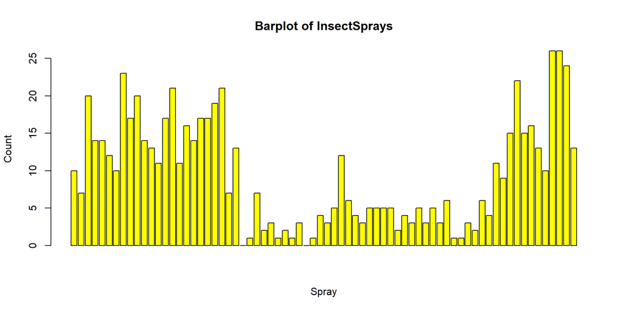

```r
barplot(InsectSprays$count,xlab="Spray",ylab="Count",main="Barplot of InsectSprays",col="yellow")
```

- http://www.r-bloggers.com/a-quick-primer-on-split-apply-combine-problems/

### Another way - split

```r
spIns <-split(InsectSprays$count,InsectSprays$spray)
spIns
```

```
$A
 [1] 10  7 20 14 14 12 10 23 17 20 14 13

$B
 [1] 11 17 21 11 16 14 17 17 19 21  7 13

$C
 [1] 0 1 7 2 3 1 2 1 3 0 1 4

$D
 [1]  3  5 12  6  4  3  5  5  5  5  2  4

$E
 [1] 3 5 3 5 3 6 1 1 3 2 6 4

$F
 [1] 11  9 15 22 15 16 13 10 26 26 24 13
```

```r
# You get the list of the values for A,B,C, etc
sprCount <-lapply(spIns,sum)
sprCount
```

```
$A
[1] 174

$B
[1] 184

$C
[1] 25

$D
[1] 59

$E
[1] 42

$F
[1] 200
```

```r
# We may want to go back to a vector
unlist(sprCount)
```

```
  A   B   C   D   E   F
174 184  25  59  42 200
```

```r
# Sapply
sapply(spIns,sum)
```

```
  A   B   C   D   E   F
174 184  25  59  42 200
```

## Another way - plyr package

```r
library(plyr)
ddpInsectSprays <-ddply(InsectSprays,.(spray),summarize,sum=sum(count))
ddpInsectSprays
```

```
  spray sum
1     A 174
2     B 184
3     C  25
4     D  59
5     E  42
6     F 200
```

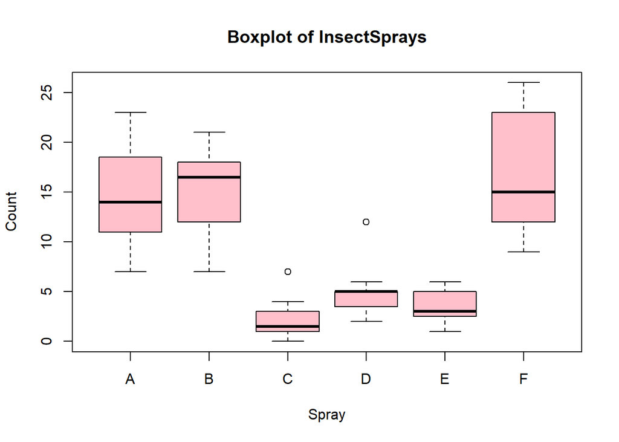

```r
# Boxplot of InsectSprays
boxplot(count~spray,xlab="Spray",ylab="Count",main="Boxplot of InsectSprays",col="pink",data=InsectSprays)
```

- Here we want to summarize spray by summing the count.

### Creating a new variable

```r
spraySums <-ddply(InsectSprays,.(spray),summarize,ave=ave(count))
dim(spraySums)
```

```
[1] 72  2
```

```r
head(spraySums)
```

```
  spray  ave
1     A 14.5
2     A 14.5
3     A 14.5
4     A 14.5
5     A 14.5
6     A 14.5
```

```r
# we can also use sum,mean,median etc to compute this
```

### More information

- A tutorial from the developer of plyr - http://plyr.had.co.nz/09-user/
- A nice reshape tutorial http://www.slideshare.net/jeffreybreen/reshaping-data-in-r
- A good plyr primer-http://www.r-bloggers.com/a-quick-primer-on-split-apply-combine-problems/
- See also the functions;
1. acast; for casting as multi-dimensional arrays.
2. arrange; for faster reordering without using order() commands.
3. mutate; for adding new variables.

### Managing dataframes with dplyr - Introduction

- dplyr is designed to help you work with data frames.

### dplyr(basic assumptions)

- The data frame is a key data structure in statistics and in R[Tidy data].
- There is one observation per row.
- Each column represents a variable or measure or characteristic.
- Primary implementation that you will use is the default R implementation.
- Other implementations particularly relational databases systems.
- Developed by Hadley Wickham of Rstudio.
- An optimized and distilled version of plyr package (also by Hadley Wickham).
- Does not provide any “new” functionality per se, but greatly simplifies existing functionality in R.
- Provides a “grammar” (in particular,verbs) for data manipulation.
- Is very fast, as many key operations are coded in c++.

### dplyr verbs (basic)

- select: return a subset of the columns of a data frame. Focuses on the columns. Use column names rather than the indices.
- filter: extract a subset of rows from a data frame based on logical conditions. Focus is on rows.
- arrange: re-order rows of a data frame while preserving the order of the columns. Focus is on rows.
- rename: rename variables in a data frame. Focus is on columns.
- mutate: add new variables/columns or transform existing variables. Focus is on columns.
- summarise/summarize: generate summary statistics of different variables in the data frame possibly within strata.
- There is also a handy print method that prevents you from printing a lot of data to the console.
- The acronym is FARMS: F for filter, A for arrange,R for rename, M for mutate and S for select.

### dplyr properties

- The first argument is a data frame.
- The subsequent arguments describe what to do with it, and you can refer to columns in the data frame directly without using the $ operator (just use the names).
- The result is a new data frame.
- Data frames must be properly formatted and annotated for this to all be useful.

### Managing data frames with dplyr - Basic Tools

### Select

```r
library(dplyr)
data(airquality)
dim(airquality)
```

```
[1] 153   6
```

```r
names(airquality)
```

```
[1] "Ozone"   "Solar.R" "Wind"    "Temp"    "Month"   "Day"
```

```r
glimpse(airquality)
```

```
Observations: 153
Variables: 6
$ Ozone   <int> 41, 36, 12, 18, NA, 28, 23, 19, 8, NA, 7, 16, 11, 14, ...
$ Solar.R <int> 190, 118, 149, 313, NA, NA, 299, 99, 19, 194, NA, 256,...
$ Wind    <dbl> 7.4, 8.0, 12.6, 11.5, 14.3, 14.9, 8.6, 13.8, 20.1, 8.6...
$ Temp    <int> 67, 72, 74, 62, 56, 66, 65, 59, 61, 69, 74, 69, 66, 68...
$ Month   <int> 5, 5, 5, 5, 5, 5, 5, 5, 5, 5, 5, 5, 5, 5, 5, 5, 5, 5, ...
$ Day     <int> 1, 2, 3, 4, 5, 6, 7, 8, 9, 10, 11, 12, 13, 14, 15, 16,...
```

```r
summary(airquality)
```

```
     Ozone           Solar.R           Wind             Temp
 Min.   :  1.00   Min.   :  7.0   Min.   : 1.700   Min.   :56.00
 1st Qu.: 18.00   1st Qu.:115.8   1st Qu.: 7.400   1st Qu.:72.00
 Median : 31.50   Median :205.0   Median : 9.700   Median :79.00
 Mean   : 42.13   Mean   :185.9   Mean   : 9.958   Mean   :77.88
 3rd Qu.: 63.25   3rd Qu.:258.8   3rd Qu.:11.500   3rd Qu.:85.00
 Max.   :168.00   Max.   :334.0   Max.   :20.700   Max.   :97.00
 NA's   :37       NA's   :7
     Month            Day
 Min.   :5.000   Min.   : 1.0
 1st Qu.:6.000   1st Qu.: 8.0
 Median :7.000   Median :16.0
 Mean   :6.993   Mean   :15.8
 3rd Qu.:8.000   3rd Qu.:23.0
 Max.   :9.000   Max.   :31.0
```

```r
airqSelect <-select(airquality,Solar.R:Temp)
head(airqSelect)
```

```
  Solar.R Wind Temp
1     190  7.4   67
2     118  8.0   72
3     149 12.6   74
4     313 11.5   62
5      NA 14.3   56
6      NA 14.9   66
```

```r
airqSelect2 <-select(airquality,-(Month:Day))
head(airqSelect2)
```

```
  Ozone Solar.R Wind Temp
1    41     190  7.4   67
2    36     118  8.0   72
3    12     149 12.6   74
4    18     313 11.5   62
5    NA      NA 14.3   56
6    28      NA 14.9   66
```

### filter

```r
library(dplyr)
airqFilter <-filter(airquality,airquality$Ozone>40)
airqFilter
```

```
   Ozone Solar.R Wind Temp Month Day
1     41     190  7.4   67     5   1
2     45     252 14.9   81     5  29
3    115     223  5.7   79     5  30
4     71     291 13.8   90     6   9
5    135     269  4.1   84     7   1
6     49     248  9.2   85     7   2
7     64     175  4.6   83     7   5
8     77     276  5.1   88     7   7
9     97     267  6.3   92     7   8
10    97     272  5.7   92     7   9
11    85     175  7.4   89     7  10
12    48     260  6.9   81     7  16
13    61     285  6.3   84     7  18
14    79     187  5.1   87     7  19
```

[output cut: 31 more lines]

```r
airqFilter2 <-filter(airquality,airquality$Ozone>40&airquality$Temp>70)
airqFilter2
```

```
   Ozone Solar.R Wind Temp Month Day
1     45     252 14.9   81     5  29
2    115     223  5.7   79     5  30
3     71     291 13.8   90     6   9
4    135     269  4.1   84     7   1
5     49     248  9.2   85     7   2
6     64     175  4.6   83     7   5
7     77     276  5.1   88     7   7
8     97     267  6.3   92     7   8
9     97     272  5.7   92     7   9
10    85     175  7.4   89     7  10
11    48     260  6.9   81     7  16
12    61     285  6.3   84     7  18
13    79     187  5.1   87     7  19
14    63     220 11.5   85     7  20
```

[output cut: 30 more lines]

### arrange

```r
library(dplyr)
airqArrange <-arrange(airquality,Day)
head(airqArrange,10)
```

```
   Ozone Solar.R Wind Temp Month Day
1     41     190  7.4   67     5   1
2     NA     286  8.6   78     6   1
3    135     269  4.1   84     7   1
4     39      83  6.9   81     8   1
5     96     167  6.9   91     9   1
6     36     118  8.0   72     5   2
7     NA     287  9.7   74     6   2
8     49     248  9.2   85     7   2
9      9      24 13.8   81     8   2
10    78     197  5.1   92     9   2
```

```r
airqArrange2 <-arrange(airquality,desc(Month))
head(airqArrange2)
```

```
  Ozone Solar.R Wind Temp Month Day
1    96     167  6.9   91     9   1
2    78     197  5.1   92     9   2
3    73     183  2.8   93     9   3
4    91     189  4.6   93     9   4
5    47      95  7.4   87     9   5
6    32      92 15.5   84     9   6
```

### rename

```r
#library(dplyr)
#airqRename <-rename(airquality,SolarRadiation=Solar.R,Temperature=Temp)
#head(airqRename)
```

### mutate

```r
airqMutate <-mutate(airquality,Tempdetrend=Temp-mean(Temp,na.rm=TRUE))
head(select(airqMutate,Temp,Tempdetrend))
```

```
  Temp Tempdetrend
1   67  -10.882353
2   72   -5.882353
3   74   -3.882353
4   62  -15.882353
5   56  -21.882353
6   66  -11.882353
```

```r
airqMutate2 <-mutate(airquality,tempcat=factor(1*(Temp>80),labels=c("cold","hot")))
hotcold <-group_by(airqMutate2,tempcat)
hotcold
```

```
# A tibble: 153 x 7
# Groups:   tempcat [2]
   Ozone Solar.R  Wind  Temp Month   Day tempcat
   <int>   <int> <dbl> <int> <int> <int> <fct>
 1    41     190   7.4    67     5     1 cold
 2    36     118   8      72     5     2 cold
 3    12     149  12.6    74     5     3 cold
 4    18     313  11.5    62     5     4 cold
 5    NA      NA  14.3    56     5     5 cold
 6    28      NA  14.9    66     5     6 cold
 7    23     299   8.6    65     5     7 cold
 8    19      99  13.8    59     5     8 cold
 9     8      19  20.1    61     5     9 cold
10    NA     194   8.6    69     5    10 cold
# ... with 143 more rows
```

### Summarize function

```r
summarize(hotcold,Temp=mean(Temp),Wind=max(Wind),Ozone=median(Ozone,na.rm=TRUE))
```

```
      Temp Wind Ozone
1 77.88235 20.7  31.5
```

### Use mutate function to create a year variable

1. chicago <-mutate(chicago,year=as.POSIXlt(date)$year+1900)
2. years <-group_by(chicago,year)
3. summarize(years,pm25=mean(pm25,na.rm=TRUE),03=max(03tmean2),no2=median(no2tmean2))

### Pipeline Operator

- chicago%>%mutate(month=as.POSIXlt(date)$mon+1)%>%group_by(month)%>%summarize(pm25=mean(pm25,na.rm=TRUE),03=max(03tmean2),no2=median(no2tmean2))

### Additional benefits of dplyr

- dplyr can work with other data frame “backends”.
- data.table for large fast tables.
- SQL interface for relational databases via DBI package.

## Merging Data

- Peer review experiment data; http://www.plosone.org/article/info:doi/10.1371/journal.pone.0026895
- Peer review data; if(!file.exists(“./data”)){dir.create(“./data”)}
- fileUrl1 <-“https://dl.dropboxusercontent.com/u/7710864/data/reviews-apr29.csv”
- fileUrl2 <-“https://dl.dropboxusercontent.com/u/7710864/data/solutions-apr29.csv”
- download.file(fileUrl1,destfile=“./data/reviews.csv”,method=“curl”).for windows ignore method=“curl”.
- download.file(fileUrl2,destfile=“./data/solutions.csv”,method=“curl”)
- reviews <-read.csv(“./data/reviews.csv”)
- solutions <-read.csv(“./data/solutions.csv”)
- head(reviews,2)
- head(solutions,2)

### Merging data - merge()

- Merges data frame.
- Important parameters: X,Y,by.X,by.Y,all.
- names(reviews).
- names(solutions).
- Important variables to merge are X and Y, you can use by, by.x, by.y, all.
- By default it merges by all the columns that have a common name.
- mergeData <-merge(reviews,solutions,by.x=“solution_id”,by.y=“id”,all=TRUE).
- head(mergeData)

### Default - merge all common column names

- intersect(names(solutions),names(reviews))
- mergeData2 <-merge(reviews,solutions,all=TRUE)
- head(mergeData2)

## Using Join in the plyr package

- Faster, but less full featured - defaults to left join, see help file for more.

```r
library(dplyr)
df1 <-data.frame(id=sample(1:10),x=rnorm(10))
df2 <-data.frame(id=sample(1:10),y=rnorm(10))
arrange(join(df1,df2),id)
```

```
   id           x           y
1   1 -0.97613156  0.42372879
2   2  0.03195218  0.01020162
3   3 -0.24336703 -0.51514175
4   4 -1.39730710  1.90548427
5   5  0.90657142  0.78181399
6   6 -1.08490770 -1.19699783
7   7  1.60835190 -0.03328190
8   8 -0.15347801 -0.57759908
9   9  0.44956355  2.46247056
10 10  0.25839364  0.63808806
```

- Join is a bit faster than merge but less full featured.

### If you have multiple data frames

- If you have multiple data frames it is challenging to use merge. If you have a common id it is very straight forward to use join.

```r
df1<-data.frame(id=sample(1:10),x=rnorm(10))
df2<-data.frame(id=sample(1:10),y=rnorm(10))
df3<-data.frame(id=sample(1:10),z=rnorm(10))
dfList<-list(df1,df2,df3)
join_all(dfList)
```

```
   id          x           y          z
1   1 -2.0998774  0.71530981  1.5713567
2   2 -1.4593416 -1.41247437  0.8075856
3   6 -0.6364289  0.66173789 -0.9797334
4   8  0.5297798  0.46045659 -0.2118462
5   3  0.9168667 -0.96991402  0.1721970
6   4 -0.4077979 -0.94285432 -0.3632936
7   7  0.6225807  0.73844626 -0.6818338
8  10 -0.2355798  2.05873499  2.5119458
9   5 -0.0269680  2.28926103  0.2490439
10  9  0.8091287  0.01280602  1.1312860
```

### More on merging data

- The quick R data merging page-http://www.statmethods.net/management/merging.html
- plyr information - http://plyr.had.co.nz/
- Types of joins - http://en.wikipedia.org/wiki/Join_(SQL)

## Editing Text Variables

- Example - Baltimore camera data.

### Fixing Character vectors-tolower(),toupper()

1. if(!file.exists(“./data”)){dir.create(“./data”)}
2. fileUrl <-“https://data.baltimorecity.gov/api/views/dz542aru/rows.csv?access=DOWNLOAD”
3. download.file(fileUrl,destfile=“./data/cameras.csv”)
4. cameraData <-read.csv(“./data/cameras.csv”)
5. names(cameraData)
6. tolower(names(cameraData))
- tolower gives you all the letters in the names in lowercase.
- toupper command gives you all the letters in uppercase.

### Fixingh Character vectors - strsplit()

- Good for automatically splitting variable names.
- Important parameters: x,split.
- Values separated by periods. e.g. Location.1
- splitNames <-strsplit(names(cameraData),“\.”). “\.” split on periods.
- splitNames[[5]]. [1]“intersection”. [[5]] represents the fifth column name in the dataframe.
- splitNames[[6]]. [1]“Location” “1”. Location.1 is split into Location and 1.

### Quick aside - lists

```r
mylist <-list(letters=c("A","b","c"),numbers=1:3,matrix(1:25,ncol=5))
head(mylist)
```

```
$letters
[1] "A" "b" "c"

$numbers
[1] 1 2 3

[[3]]
     [,1] [,2] [,3] [,4] [,5]
[1,]    1    6   11   16   21
[2,]    2    7   12   17   22
[3,]    3    8   13   18   23
[4,]    4    9   14   19   24
[5,]    5   10   15   20   25
```

```r
mylist[1]
```

```
$letters
[1] "A" "b" "c"
```

```r
mylist$letters
```

```
[1] "A" "b" "c"
```

```r
mylist[[1]]
```

```
[1] "A" "b" "c"
```

### Fixing Character vectors - sapply()

- Applies a function to each element in a vector or list.
- Important parameters: X,FUN.
- splitNames[[6]][1]. [1]“Location”.
- firstElement <-function(x){x[1]}
- sapply(splitNames,firstElement)

### Fixing Character vector - sub()

- Important parameters: pattern,replacement,X.
- names(reviews)
- sub("_“,”",names(reviews),). This command removes underscore.

### Fixing Character vectors - gsub()

- testName <-“this_is_a_test”
- sub("_“,”“,testName).[1]”this is _a_test".
- gsub("_“,”“,testName).[1]”this is a test".
- gsub removes multiple underscore.

### Finding values - grep(), grepl()

- grep(“Alameda”,cameraData$intersection).[1]4 5 36.
- table(grepl(“Alameda”,cameraData$intersection)). FALSE 77 TRUE 3.
- cameraData2 <-cameraData[!grepl(“Alameda”,cameraData$intersection),].

### More on grep()

- grep(“Alameda”,cameraData$intersection,value=TRUE).[1]“The Alameda & 33rd st”.
- grep(“JeffStreet”,cameraData$intersection).[1]integer(0).

### More useful string functions

1. library(stringr)
2. nchar(“Jeffrey Leek”).[1] 12.
3. substr(“Jeffrey Leek”,1,7).[1]“Jeffrey”. 1,7 is the 1st to the 7th letter.
4. paste(“Jeffrey”,“Leek”).[1]“Jeffrey Leek”
- paste; pastes two strings together separated by a space. You can actually set the separation with the sep argument.
5. paste0(“Jeffrey”,“Leek”).[1]“JeffreyLeek”.
- paste0; pastes with no space.
6. str_trim(“Jeff”).[1]“Jeff”. str_trim trims excess space.

### Important points about text in data sets

- Names of variables should be;
1. All lower case when possible.
2. Descriptive(Diagnosis versus Dx).
3. Not duplicated.
4. Not have underscores or dots or white spaces.
- Variables with character values;
1. Should usually be made into factor variables(depends on application).
2. Should be descriptive(use TRUE/FALSE instead of 0/1 and Male/Female versus 0/1 or M/F).

### Regular Expressions I

- Regular expressions can be thought of as a combination of literals and metacharacters.
- To draw an analogy with natural language, think of literal text forming the words of this language, and the metacharacters defining its grammar.
- Regualar expressions have a rich set of metacharacters.

### Literals

- Simplest pattern consists only of literals. The literal “nuclear” would match to the following lines:
1. Literals; words that match exactly in differnt lines.

### Regular Expressions

1. Simplest pattern consists only of literals; a match occurs if the sequence of literals occurs anywhere in the text being tested.
2. What if we only want the word “Obama”? or sentences that end in the word “Clinton”,or “clinton”,or“clinto”?
- We need a way to express;
1. whitespace word boundaries.
2. sets of literals.
3. the beginning and end of a line.
4. alternatives(“war” or “peace”) Metacharacters to the rescue!

### Metacharacters

- Some metacharacters represent the start of a line ^ i think will match the lines; i think we all rule for participating; i think i have been ousted;… i think i first saw zombo in 1999.
- $ represents the end of a line e.g. morning$ will match the lines morning when morning is the last word. When morning appears in the middle of the text, it won’t match.

### Character Classes with [ ]

- We can list a set of characters we will accept at a given point in the match. [Bb] [Uu] [Ss] [Hh] will match the lines with the word/name Bush both lowercase and uppercase anywhere in the text.
- ^ [Ii] am will match all the I am/i am at the beginning of the line.
- Similarly, you can specify a range of letters [a-z] or [a-zA-Z]; notice that the order doesn’t matter.
- ^ [0-9][a-zA-Z] will match any number between 0 and 9 at the beginning of the line followed by a letter.
- When used at the beginning of a character class, the "" is also a metacharacter and indicates matching characters NOT in the indicated class.
- [^?.]$ will match the lines with $ at the end and ?. at the beginning.

### More Metacharacters: | (or)

- This does not mean “pipe” in the context of regular expressions; instead it translates to “or”; we can use it to combine two expressions, the subexpressions being called alternatives. Flood | fire will match the lines flood or fire in every line.
- “.” is used to refer to any character. So 9.11 will match 9-11,9/11,203.169.114.66,9:11:46AM.

### More Metacharacters: |

- We can include any number of alternatives…
- flood | earthquake | huricane | coldfire will match the lines containing each of these words.
- The alternatives can be real expressions and not just literals.
- ^ [Gg]ood | [Bb]ad will match the lines Good/good in the beginning of the line or Bad/bad anywhere in the text not necessarily at the beginning of the line.
- bad has not got ^ infront.

### More Metacharacters: (and)

- Subexpressions are often contained in parenthesis to constrain the alternatives.
- ^ ([Gg]ood | [Bb]ad) will match the lines Bad/bad or Good/good at the beginning of the line.

### More Metacharacters: ?

- The question mark indicates that the indicated expression is optional.
- [Gg]eorge([Ww].)? [Bb]ush. So ([Ww].)? is optional. This will match the line george bush because it does not necessarily have to have W in the middle.
- One thing to note. In the following [Gg]eorge([Ww].)? [Bb]ush we wanted to match a “.” as a literal period; to do that we had to “escape” the metacharacter, preceeding it with a backlash. In general, we have to this for any metacharacter we want to include in our match.

### More Metacharacter: * and +

- The * and + signs are metacharacters used to indicate repetition; * means “any number, including none of the item” and + means " at least one of the item".
- (.*) will match the lines (24,m,germany), ().
- [0-9] + (.*) [0-9] + will match the lines with any number of possible combinations of at least one number that are separated by something other than numbers.

### More Metacharacters: {and}

- {and} are referred to as interval quantifiers; then let us specify the minimum and maximum number of matches of an expression.
- [Bb]ush (+[^]+ +){1,5} debate will match the lines 1 space + something not a space + space between 1 to 5. There are 5 words between Bush/bush and debate etc.

### More Metacharacters: (and) revisited

- In most implementations of regular expressions, the parentheses not only limit the scope of alternatives divided by a “|”, but also can be used to “remember” text matched by the subexpression enclosed.
- We refer to the matched text with \1, \2, etc. So the expression + ([a-zA-Z]+) +\1 + will match the lines night night, blah blah blah blah, all all, anybody anybody, css css css css etc.
- \1 indicates repetitions of the same phase.
- The * is “greedy” so it always matches the longest possible string that satisfies the regular expression.
- So ^ s(.*)S matches all the strings that starts with s and ends with s.
- The greediness of * can be turned off with the ?, as in ^ s(.*?)s$. We start with s followed by smaller number of strings end with an s.

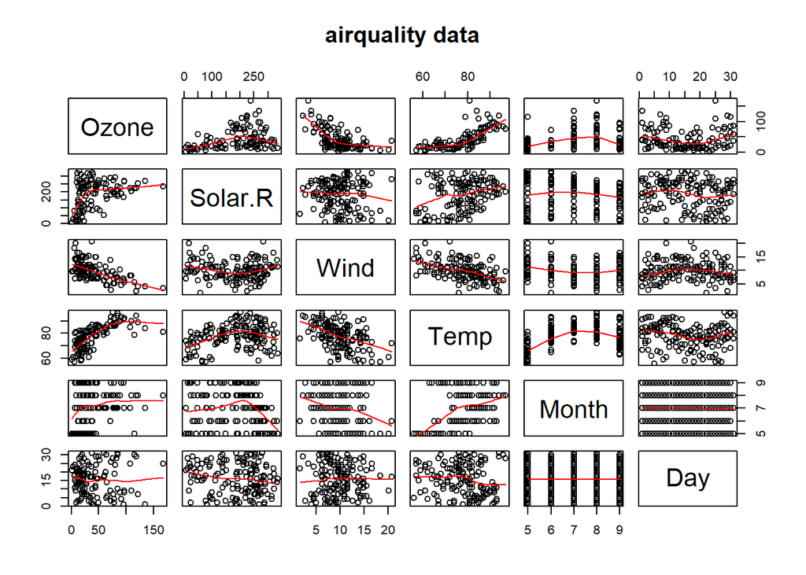

```r
library(datasets)
require(graphics)
data(airquality)
pairs(airquality,panel=panel.smooth,main="airquality data")
```

## Base graphics example

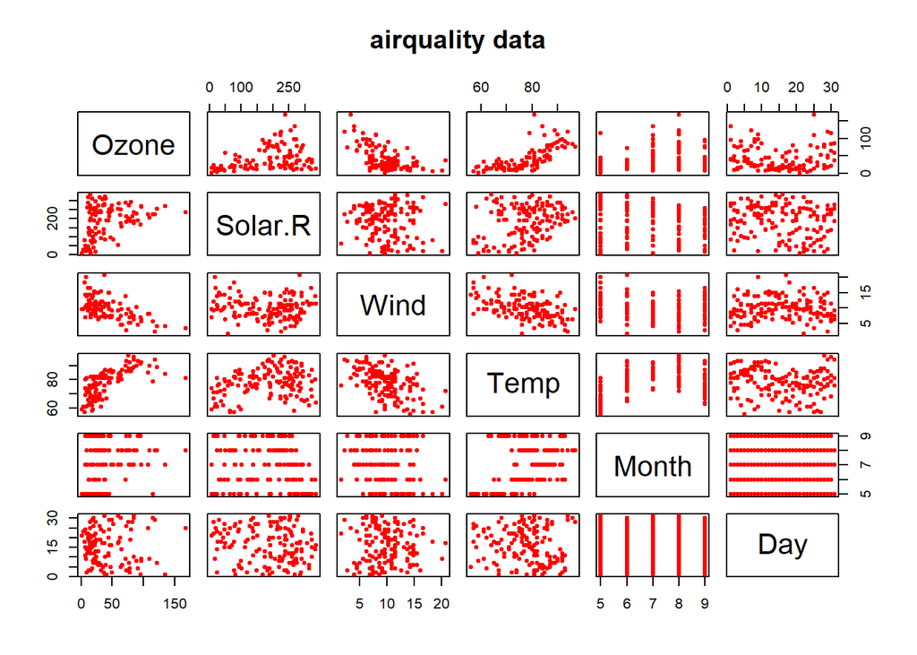

```r
plot(airquality,cex=1,pch=20,col="red",main="airquality data")
```

## Summary

- Regular expressions are used in many different languages; not unique to R.
- Regular expressions are composed of literals and metacharacters that represent sets or classes of characters/words.
- Text processing via regular expressions is a very powerful way to extract data from “unfriendly” sources (not all data comes as a CSV file).
- Used with the functions grep, grepl, sub, gsub and others that involve searching for text strings (Thanks to Mark Hansen for some material in this lecture).